# 488 - Energy Predictor Report

Nick Moreno

12/10/2019

### Introduction

For Kaggle’s “ASHRAE - GREAT ENERGY PREDICTOR III” data competition, our primary task is to develop a model that predicts energy consumption of buildings. This competition defines a building’s energy consumption through four sources - electricity, chilled and hot water, and steam - measured by per-hour building meter readings. As we are interested in prediction, the plan is to create a generalized additive model to predict hourly meter readings for each energy type based on historical building specifications and weather patterns. This model will then be evaluated using the Root Mean Squared Logarithmic Error.

The dataset we have to train our model consists of 1449 buildings and their historical meter readings for an entire year on the hour. It additionally gives data concerning the size and age of each building, as well as various temperature metrics grouped by 15 building sites. The goal is to build a model that helps companies and organizations can choose their next locations or investment opportunities based on areas that optimize energy saving and cost efficiency.

### Methods:

While we have introduced our main prediction method of choice, our dataset did not come cleaned. Thus, it’s also important to note our approach to merging our data and dealing with missing values along with the details of our GAM model.

#### Data Cleaning

Basically, actual meter readings came separate from our building and weather information. In addition, both datasets detailing building and weather information included a number of missing values for each variable:

```
##     site_id building_id primary_use square_feet  year_built floor_count
##           0           0           0           0         774        1094
```

```
##            site_id          timestamp    air_temperature
##                  0                  0                 55
##     cloud_coverage    dew_temperature  precip_depth_1_hr
##              69173                113              50289
## sea_level_pressure     wind_direction         wind_speed
##              10618               6268                304
```

To deal with this, I decided to fill in the missing values using the mice() function in R. I utilized the function to create a mean matching-based predictive model that imputes values for each missing data point.

There are missing values for building year, floor count, and each weather metric. Because mice uses a collection of predictors in a dataset, it made more sense to build the values before merging the dataset, so only weather variables are being used to predict weather missing values (same for building). So, I used mice independently on building data and then weather data.

It also occured to me that I may want to use specific time metrics when modeling, so I deconstructed the timestamp to create five new predictors; hour, day of the week, numerical day, month, and year. I used lubridate(), a popular R function that simply accesses a timestamp and exploits specific pieces.

Once the missing data was handled, I merged the data into one training and one test set that we will use for modeling. It’s worth noting that missing values arose again after the final merge, so I used the same function but, rather than mean matching, I chose a simply random sample method as it was a small percentage of our overall data

#### EDA

I went with a GAM model mainly because of our relatively small amount of predictor variables. Even with creating five new predictors, we are still only left with 20 predictors. My thought was that I would be able to try many different combinations of predictors - all of whom may have different relationships with meter readings - in a relatively small amount of time to see what performed the best. To choose which predictors to use, and the parameters of each method used to transform the predictor, I needed to take a deeper look into the set of variables at hand.

Off the bat, I knew three of them would not be of any real use - *timestamp* is taken care of by the new time predictors, *time.year* only has one value (2016), and creating four different meter type models renders *meter_type* useless. For the rest of the predictors, I always like to run a simple correlation matrix between the response and all of the predictors. I ran correlations of meter readings with building and weather data for each meter type:

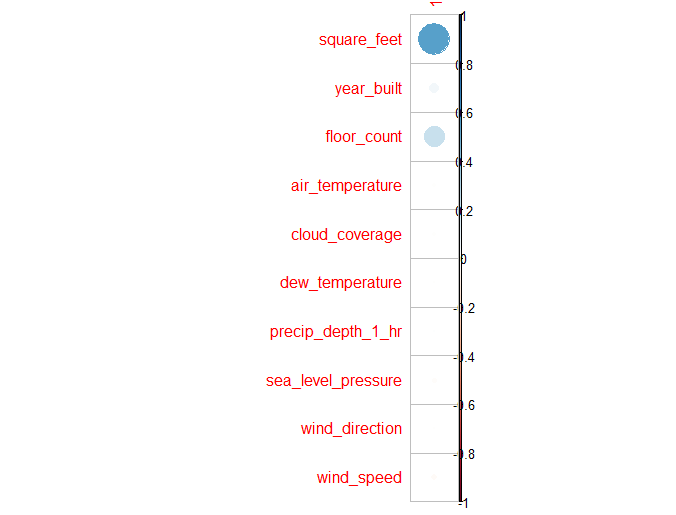

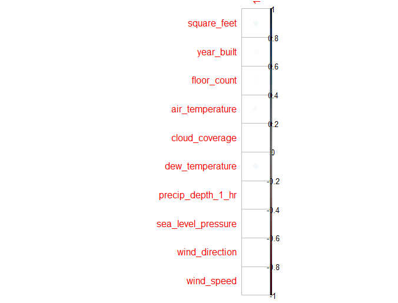

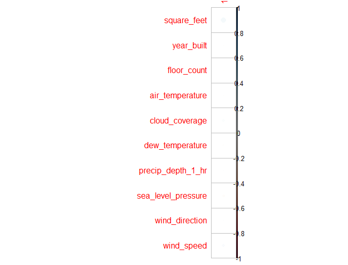

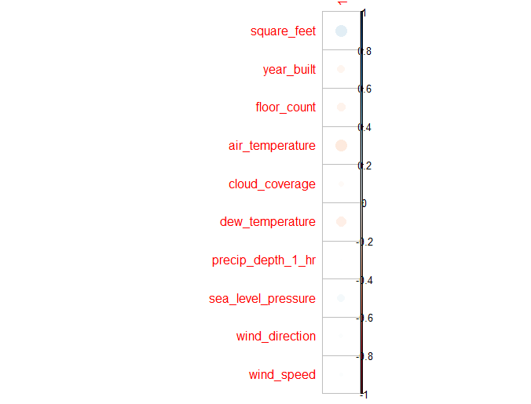

Because there was positive correlation of meter reading and square feet with all four meter types, and positive correlation of meter reading and year with meters 0 and 1, I included these as predictors through natural cubic spline with five knots. I went with 5 because that gave me the best rmsle error. The weather predictors had virtually no correlation, but I decided to include them anyways because of my lack of predictor options. However, because I included every weather predictor, I took out *site_id* because I felt the differences in building sites are explained through the weather and I did not want to build a model that considered buiilding groups.

Next, I considered the time metrics. I wanted to select the smallest amount of time predictors, so I thought about what time metrics energy usage depended on. Thus, I elected to go with month, day of the week, and time of day. Both energy consumption and weather patterns would likely depend on these three when considering average time of building usage, seasonal change, etc., so I created plots to back my assumption:

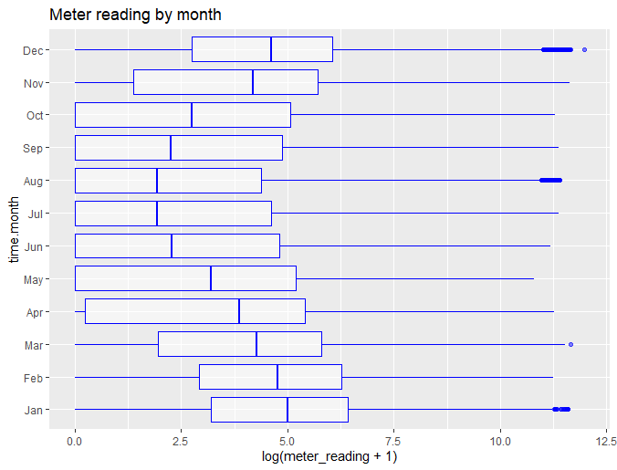

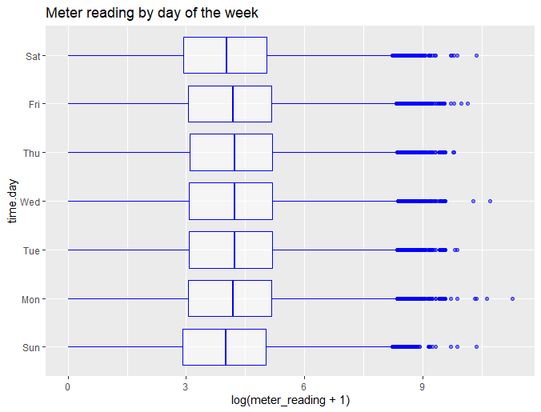

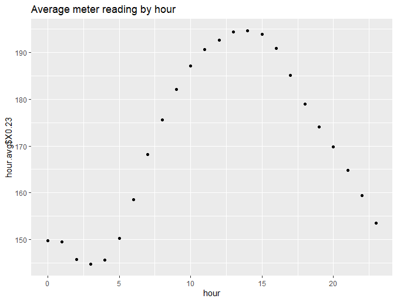

So we will include these in our GAM model.

As some finishing touches, I looked at the distribution of meter readings themselves to learn more information by taking the average meter reading by building. I then found a few anomolies:

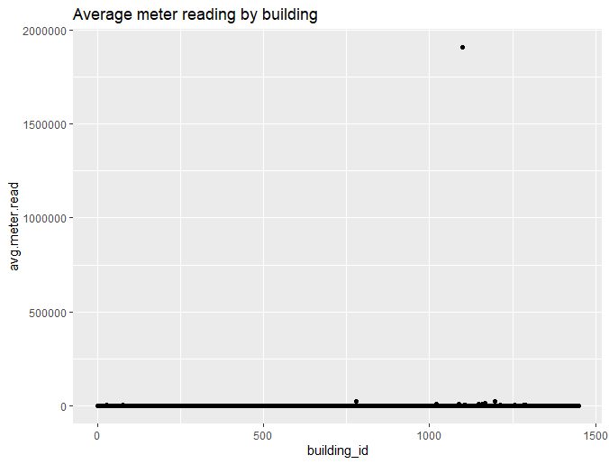

I did not want to remove these buildings, so a log transformation should standardize the response variables quite a bit:

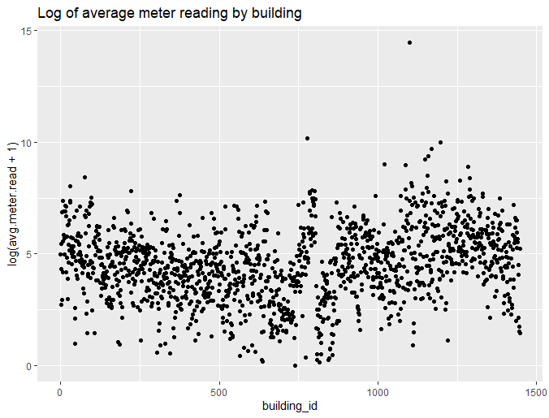

Now that our meter readings are usable, my final improvement to modeling was to confirm my assumptions of some variability with meter type. This was analyzed through a simple plot:

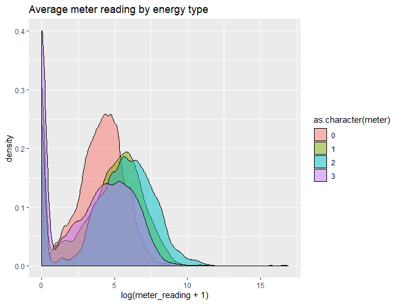

The plot shows an obvious difference between electricity and hot water with cold water and steam. Thus, I’ll fit four different models separated by the type of energy measured from each meter. With all of this into account, I created predictions and submitted to Kaggle.

### Results

My Root Mean Square Log Error Kaggle calculated upon my submission was 1.66 - more than clearing the benchmark and currently in 2862nd place.

### Conclusion / Future Work

The first obvious area for future improvement would be k-fold cross validation. When building my model, I did not aim to lower prediction error by creating training and testing folds and leaving a fold out to train a model. This could improve the model’s overall accuracy without much added work. Additionally, I initially attempted to fit a random forest with boosting so I didn’t have to omit any variables in the model consideration, but my computer would not handle anything over 100 trees with cross validation, so I wasn’t able to beat my GAM prediction error. I could try to run this in the future on a PC that could handle this type of model.

### Appendix

```r
library(lubridate)
library(mice)
library(ggplot2)
library(dplyr)
library(gam)
library(mltools)
library(corrplot)

      ### Start Data ###

train <- read.csv("/Users/Tervs/Documents/488 Final - Energy/datasets/train.csv")
test <- read.csv("/Users/Tervs/Documents/488 Final - Energy/datasets/test.csv")
building <- read.csv("/Users/Tervs/Documents/488 Final - Energy/datasets/building_metadata.csv")
weather.train <- read.csv("/Users/Tervs/Documents/488 Final - Energy/datasets/weather_train.csv")
weather.test <- read.csv("/Users/Tervs/Documents/488 Final - Energy/datasets/weather_test.csv")
sample <- read.csv("/Users/Tervs/Documents/488 Final - Energy/datasets/sample_submission.csv")

      ### Missing data ###


## Building NA's

#Want to use all but building ID for prediction
init.b <- mice(building, maxit = 1)
meth.b <- init.b$meth
predM.b <- init.b$predictorMatrix
#remove building ID (both for imputation and prediction)
predM.b[ ,c("building_id")] = 0
#create new building dataset
imput.b <- mice(building, method = meth.b, predictorMatrix = predM.b, m=5)
final.b <- complete(imput.b)

## Weather NA's

#Training Set
#We need to separate "timestamp" so we can use it as numeric
as_datetime(weather.train$timestamp)
time.hour <- hour(weather.train$timestamp)
time.day <- day(weather.train$timestamp)
time.month <- month(weather.train$timestamp)
time.year <- year(weather.train$timestamp)
new.time <- cbind.data.frame(time.hour, time.day, time.month, time.year)
#Now we can add to our training data
weather.train <- subset(weather.train, select = -c(timestamp))
weather.train <- cbind.data.frame(new.time, weather.train)
#We want all of them used
init.w <- mice(weather.train, maxit = 0)
meth.w <- init.w$method
predM.w <- init.w$predictorMatrix
#create new weather dataset
imput.w <- mice(weather.train, predictorMatrix = predM.w, m=1)
imput.w <- complete(imput.w)
final.w <- imput.w
final.train <- final.w
#Let's clean up some unwanted datasets
rm(building, weather.train)
rm(imput.w, init.w, predM.w, meth.w)
rm(time.day, time.hour, time.month, time.year, timestamp.n)

#Test set
#We need to separate "tiemestamp" so we can use it as numeric
as_datetime(weather.test$timestamp)
time.hour <- hour(weather.test$timestamp)
time.day <- day(weather.test$timestamp)
time.month <- month(weather.test$timestamp)
time.year <- year(weather.test$timestamp)
new.time <- cbind.data.frame(time.hour, time.day, time.month, time.year)
#Now we can add to our training data
weather.test <- subset(weather.test, select = -c(timestamp))
weather.test <- cbind.data.frame(new.time, weather.test)
#We want all of them used
init.w <- mice(weather.test, maxit = 0)
meth.w <- init.w$method
predM.w <- init.w$predictorMatrix
#create new weather dataset
imput.w <- mice(weather.test, predictorMatrix = predM.w, m=1)
imput.w <- complete(imput.w)
final.test <- imput.w

#Clean up
#Let's clean up some unwanted datasets and rename our created sets
# rm(weather.test)
# rm(imput.w, init.w, predM.w, meth.w)
# rm(time.day, time.hour, time.month, time.year, new.time, timestamp.n)
# rm(final.w)
# final.w.train <- final.train
# final.w.test <- final.test
# rm(final.train, final.test)

      ### Timestamp ###
#Before we can merge, we need to standardize where timestamp appears:
#Timestamp is in train, test, final.train, final.test
#We need to perform deconcatenatino on train, test, and add day to final.train, final.test

#Train
as_datetime(train$timestamp)
train.hour <- hour(train$timestamp)
train.day <- wday(train$timestamp, label = TRUE)
train.date <- day(train$timestamp)
train.month <- month(train$timestamp, label = TRUE)
train.year <- year(train$timestamp)
new.train <- cbind.data.frame(train.hour, train.day, train.date, train.month, train.year)
new.train <- cbind.data.frame(new.train, train)
new.train <- subset(new.train, select = -c(timestamp))
final.train <- new.train
rm(new.train)

#Test
as_datetime(test$timestamp)
test.hour <- hour(test$timestamp)
test.day <- wday(test$timestamp, label = TRUE)
test.date <- day(test$timestamp)
test.month <- month(test$timestamp, label = TRUE)
test.year <- year(test$timestamp)
new.test <- cbind.data.frame(test.hour, test.day, test.date, test.month, test.year)
new.test <- cbind.data.frame(new.test, test)
new.test <- subset(new.test, select = -c(timestamp))
final.test <- new.test
rm(new.test)

#w.train
time.day <- wday(weather.train$timestamp, label = TRUE)
time.date <- day(weather.train$timestamp)
final.w.train <- cbind.data.frame(final.w.train, time.day, time.date)
final.w.train <- subset(final.w.train, select = -c(2, 13))
final.w.train <- final.w.train[ ,c(1, 12, 13, 2, 3, 4, 5, 6, 7, 8, 9, 10, 11)]

#w.test
time.day <- wday(weather.test$timestamp, label = TRUE)
time.date <- day(weather.test$timestamp)
final.w.test <- cbind.data.frame(final.w.test, time.day, time.date)
final.w.test <- subset(final.w.test, select = -c(2))
final.w.test <- final.w.test[ ,c(1, 12, 13, 2, 3, 4, 5, 6, 7, 8, 9, 10, 11)]

#Clean up
# rm(merg.dat, test, train, weather.test, weather.train, test.date, test.day, test.hour, test.month,
#    test.year, time.date, time.day, train.date, train.day, train.hour, train.month, train.year)
#

         ### Data merge ###



#Training set merge - first building meta w/ train
merg.dat <- merge(final.train, final.b, by.x = "building_id", by.y = "building_id", all.x = TRUE)

#Then with weather train data
colnames(merg.dat)[2] <- "time.hour"
colnames(merg.dat)[3] <- "time.day"
colnames(merg.dat)[4] <- "time.date"
colnames(merg.dat)[5] <- "time.month"
colnames(merg.dat)[6] <- "time.year"
final.w.train$time.month <- month(final.w.train$time.month, label = TRUE)
train.full <- merge(merg.dat, final.w.train, by.x = c("time.hour", "time.day", "time.date", "time.month", "time.year", "site_id"),
                    by.y = c("time.hour", "time.day", "time.date", "time.month", "time.year", "site_id"), all.x = TRUE)

#So, we still have NA's, but way less than before AND the same amount for each weather predictor. This shoud be easy to fix later.
```

```r
#Test set merge - merge building meta w/ test
merg.dat.test <- merge(final.test, final.b, by.x = "building_id", by.y = "building_id", all.x = TRUE)

#Then with weather test data
colnames(merg.dat.test)[2] <- "time.hour"
colnames(merg.dat.test)[3] <- "time.day"
colnames(merg.dat.test)[4] <- "time.date"
colnames(merg.dat.test)[5] <- "time.month"
colnames(merg.dat.test)[6] <- "time.year"
final.w.test$time.month <- month(final.w.test$time.month, label = TRUE)
test.full <- merge(merg.dat.test, final.w.test, by.x = c("time.hour", "time.day", "time.date", "time.month", "time.year", "site_id"),
                   by.y = c("time.hour", "time.day", "time.date", "time.month", "time.year", "site_id"), all.x = TRUE)

#Clean up
# rm(merg.dat, merg.dat.test)
# rm(final.b, final.test, final.train, final.w.test, final.w.train)

#Now let's deal with our NA's

#Train
init <- mice(train.full, maxit = 0)
meth <- init$meth
predM <- init$predictorMatrix
#remove building ID (both for imputation and prediction)
meth <- "sample"
predM[ ,c("building_id", "time.hour", "time.day", "time.date", "time.month", "time.year", "meter", "meter_reading", "primary_use", "square_feet", "floor_count", "year_built")]=0
#create new building dataset
imput <- mice(train.full, method = "sample", predictorMatrix = predM, m=1)
final <- complete(imput)
train.final <- complete(imput)
rm(init, meth, predM, imput)

#Test
init <- mice(test.full, maxit = 0)
meth <- init$meth
predM <- init$predictorMatrix
#remove building ID (both for imputation and prediction)
meth <- "sample"
predM[ ,c("building_id", "time.hour", "time.day", "time.date", "time.month", "time.year", "meter", "row_id", "primary_use", "square_feet", "floor_count", "year_built")]=0
#create new building dataset
imput <- mice(test.full, method = "sample", predictorMatrix = predM, m=1)
test.final <- complete(imput)

#Clean up
# rm(train.full, test.full)
# rm(imput, init, predM, meth)

#create a new timestamp variable and move it to the front:
train.final$timestamp <- ymd_h(paste(train.final$time.year, train.final$time.month, train.final$time.date, train.final$time.hour, sep = "-"))
train.final <- train.final %>%
   select(timestamp, everything())
test.final$timestamp <- ymd_h(paste(test.final$time.year, test.final$time.month, test.final$time.date, test.final$time.hour, sep = "-"))
test.final <- test.final %>%
   select(timestamp, everything())


#separate by meter type
train.0 <- train.final[train.final$meter %in% 0,]
train.1 <- train.final[train.final$meter %in% 1,]
train.2 <- train.final[train.final$meter %in% 2,]
train.3 <- train.final[train.final$meter %in% 3,]
test.0 <- test.final[test.final$meter %in% 0,]
test.1 <- test.final[test.final$meter %in% 1,]
test.2 <- test.final[test.final$meter %in% 2,]
test.3 <- test.final[test.final$meter %in% 3,]

      ### EDA ###


#Correlations
cor.0 <- cor(train.0[12:21], train.0$meter_reading) #High cor w/ sq_ft, fl_ct
cor.1 <- cor(train.1[12:21], train.1$meter_reading)
cor.2 <- cor(train.2[12:21], train.2$meter_reading)
cor.3 <- cor(train.3[12:21], train.3$meter_reading) #slight cor w/ sq_ft, air temp
corrplot(cor.0)
corrplot(cor.1)
corrplot(cor.2)
corrplot(cor.3)


#TIME BY METER READING
ggplot(train.0, aes(x = time.day, y = log(meter_reading + 1))) +
   geom_boxplot(alpha = 0.5, colour = "blue") +
   coord_flip() +
   ggtitle("Meter reading by day of the week")
ggplot(train.3, aes(x = time.month, y = log(meter_reading + 1))) +
   geom_boxplot(alpha = 0.5, colour = "blue") +
   coord_flip() +
   ggtitle("Meter reading by month")
hour.avg <- data.frame(0:23)
rownames(hour.avg) <- 0:23
for (i in 1:24){
   hour.avg[i,] <- mean(train.0[train.0$time.hour %in% (i-1),]$meter_reading)
   print(i-1)
}
hour.avg$hour <- 0:23
ggplot(hour.avg, aes(x = hour, y = hour.avg$X0.23)) +
   geom_point() +
   ggtitle("Average meter reading by hour")

#Weekdays generally higher energy usage, Weekends less w/ sunday the smallest

#WEATHER BY METER READING PLOTS
ggplot(train.final, aes(x = air_temperature, y = log(meter_reading + 1))) +
   geom_point() +
   ggtitle("air temp by energy usage")
ggplot(train.final, aes(x = cloud_coverage, y = log(meter_reading + 1))) +
   geom_point() +
   ggtitle("cloud coverage by energy usage")
ggplot(train.final, aes(x = dew_temperature, y = log(meter_reading + 1))) +
   geom_point() +
   ggtitle("dew temp by energy usage")
ggplot(train.final, aes(x = precip_depth_1_hr, y = log(meter_reading + 1))) +
   geom_point() +
   ggtitle("precipritation depth by energy usage")
ggplot(train.final, aes(x = sea_lvl_pressure, y = log(meter_reading + 1))) +
   geom_point() +
   ggtitle("sea level pressure by energy usage")

#AVG METER READING BY BUILDING
bld.avg <- data.frame(0:1448)
rownames(bld.avg) <- 0:1448
for (i in 1:1449){
   bld.avg[i,] <- mean(train.final[train.final$building_id %in% (i-1),]$meter_reading)
   print(i-1)
}
bld.avg <- cbind(bld.avg, c(0:1448))
colnames(bld.avg) <- c("avg.meter.read", "building_id")
ggplot(bld.avg, aes(x = building_id, y = avg.meter.read)) +
   geom_point() +
   ggtitle("Average meter reading by building")
ggplot(bld.avg, aes(x = building_id, y = log(avg.meter.read+1))) +
   geom_point() +
   ggtitle("Log of average meter reading by building")

#building 1099 an anomoly - Think about omitting? avg. reading is wayyyy too high

#let's inspect further
bld.1099 <- subset(train.final, building_id == 1099)
plot(bld.1099$timestamp, log(bld.1099$meter_reading+1))

#So that looks weird, how about the other high avg. buildings?

#5 more buildings who's avg. meter read is >10,000
bld.778 <- subset(train.final, building_id == 778)
bld.1197 <- subset(train.final, building_id == 1197)
bld.1168 <- subset(train.final, building_id == 1168)
bld.1159 <- subset(train.final, building_id == 1159)
bld.1148 <- subset(train.final, building_id == 1148)
plot(bld.778$timestamp, log(bld.778$meter_reading+1))
plot(bld.1197$timestamp, log(bld.1197$meter_reading+1))
plot(bld.1168$timestamp, log(bld.1168$meter_reading+1))
plot(bld.1159$timestamp, log(bld.1159$meter_reading+1))
plot(bld.1148$timestamp, log(bld.1148$meter_reading+1))
```

```r
#Okay, so 1099 and 778 look a little off, let's compare their data to the whole set

ggplot(train.final, aes(x = log(meter_reading + 1))) +
   geom_histogram(alpha = .5) +
   ggtitle("Meter reading from all buildings")
ggplot(bld.1099, aes(x = log(meter_reading + 1))) +
   geom_histogram(alpha = .5) +
   ggtitle("Meter reading from bld 1099")
ggplot(bld.778, aes(x = log(meter_reading + 1))) +
   geom_histogram(alpha = .5) +
   ggtitle("Meter reading from bld 778")
#These are all really pulling the average, with building 1099 the worst. log transformation of response required.
rm(bld.1148, bld.1159, bld.1168, bld.1197)


#METER READING BY METER TYPE
ggplot(train.final, aes(x = log(meter_reading + 1), fill = as.character(meter))) +
   geom_density(alpha = 0.5, adjust = 2) +
   ggtitle("Average meter reading by energy type")
#So we see that electrcity uses the least amount, steam using the most.
#This is good - maybe 4 different models? 1 and 2 look similar, 0 and 3 quite different
#From here on out, we should be looking at the training set based on meter type, so let's make four new datasets.

         ### MODELING ###



#LASSO to find potentially signif. variables
train.0.matx <- model.matrix(log(meter_reading + 1) ~ primary_use square_feet + year_built + floor_count + air_temperature + cloud_coverage + dew_temperature + sea_level_pressure + wind_direction + wind_speed, data = train.0)
mdl.lasso <-cv.glmnet(train.0.matx, train.0$meter_reading, alpha = 1)
#lambda = .3097798
mdl.lasso.f <- glmnet(train.0.matx, train.0$meter_reading, alpha = 1, lambda = mdl.lasso$lambda.min)
coeff <- predict(mdl.lasso.f, type = "coefficients")[1:11,]
#Didn't really give us anything


#GAM
#Training model on train
#0 - Electricity
mdl.0 <- gam(log(meter_reading+1) ~ ns(square_feet, df = 5) + ns(year_built, df=5) + time.hour + time.month + time.day + s(air_temperature) +
                 s(cloud_coverage) + s(dew_temperature) + s(sea_level_pressure) + s(wind_direction) + s(wind_speed), data = train.0)
# pred.0 <- predict(mdl.0, newdata = train.0)
# rmsle(pred.0, log(train.0$meter_reading+1))
#1 - Chill
mdl.1 <- gam(log(meter_reading+1) ~ ns(square_feet, df = 5) + ns(year_built, df=5) + time.hour + time.month + time.day + s(air_temperature) +
                s(cloud_coverage) + s(dew_temperature) + s(sea_level_pressure) + s(wind_direction) + s(wind_speed), data = train.1)
# pred.1 <- predict(mdl.1, newdata = train.1)
# rmsle(pred.1, log(train.1$meter_reading+1))
#2 - Steam
mdl.2 <- gam(log(meter_reading+1) ~ ns(square_feet, df = 5) + time.hour + time.month + time.day + s(air_temperature) +
                s(cloud_coverage) + s(dew_temperature) + s(sea_level_pressure) + s(wind_direction) + s(wind_speed), data = train.2)
# pred.2 <- predict(mdl.2, newdata = train.2)
# rmsle(pred.2, log(train.2newdata = reading+1))
#3 - Hot
mdl.3 <- gam(log(meter_reading+1) ~ ns(square_feet, df = 5) + time.hour + time.month + time.day + s(air_temperature) +
                s(cloud_coverage) + s(dew_temperature) + s(sea_level_pressure) + s(wind_direction) + s(wind_speed), data = train.3)
# pred.3 <- predict(mdl.3, newdata = train.3)
# rmsle(pred.3, log(train.3$meter_reading+1))

#Test predictions
#0 - Electricity
newpred.0 <- predict(mdl.0, newdata = test.0)
newpred.0 <- exp(newpred.0) - 1
test.0$yhat <- newpred.0

#1 - Chill
newpred.1 <- predict(mdl.1, newdata = test.1)
newpred.1 <- exp(newpred.1) - 1
test.1$yhat <- newpred.1

#2 - Steam
newpred.2 <- predict(mdl.2, newdata = test.2)
newpred.2 <- exp(newpred.2) - 1
test.2$yhat <- newpred.2

#3 - Hot
newpred.3 <- predict(mdl.3, newdata = test.3)
newpred.3 <- exp(newpred.3) - 1
test.3$yhat <- newpred.3

#Add predictons to test set to prepare for submisison
test.preds <- rbind(test.0, test.1, test.2, test.3)
submission <- subset(test.preds, select = c(9, 22))
colnames(submission) <- c("row_id", "meter_reading")
write.csv(submission,"/Users/Tervs/Desktop/sample_submission.csv", row.names = FALSE)

#Clean-up
rm(test.final, train.final)
rm(test.final)
```